# git going with R

07 Jan 2021

## What is git?

“You use Git to take snapshots of all the files in a folder.”

[*Alice Bartlett*](https://speakerdeck.com/alicebartlett/git-for-humans)

[figure not shown]

## Snapshots in time

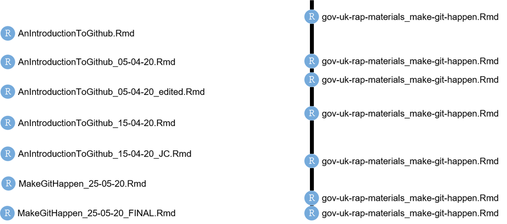

## Three key concepts

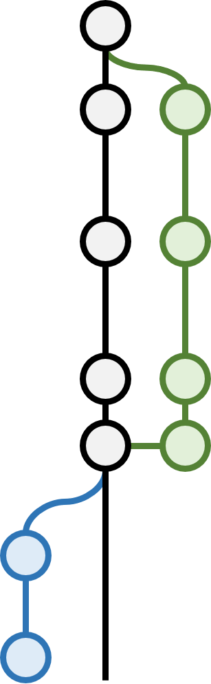

- **Repository** - your project folder
- **Commit** - a snapshot of your folder
  - We use `push` to send the snapshots online
  - And `pull` to retrieve an updated snapshot
- **Branch** - a working version of your folder

## Work `git`!

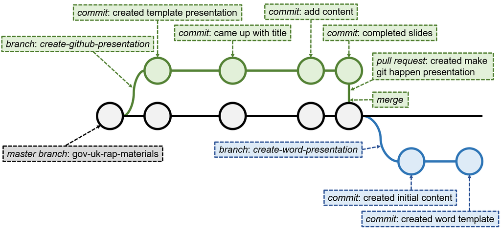

## Installing `git`

[figure not shown]

- For Windows, download the executable [here](https://git-scm.com/download/win)
- On a mac type `git --version` in your terminal
- On linux machines type `sudo apt install git-all` in your terminal

*Note that you may need admin rights on your computer, without these you’ll need to request an install.*

## Create a GitHub account

[figure not shown]

GitHub offers a range of account types. A free account is available for organisations and individuals.

Even if you’re in an institution, create a personal GitHub account to keep track of you own work.

You’ll find more information, and links for creating an account, [here](https://help.github.com/en/github/getting-started-with-github/signing-up-for-a-new-github-account).

## Create a repository

- Follow the instructions [here](https://help.github.com/en/enterprise/2.16/user/github/getting-started-with-github/create-a-repo) to create your first repository
- Some key files to include:

  `README` - ideally format this as a markdown `md` file (more info [here](https://help.github.com/en/github/creating-cloning-and-archiving-repositories/about-readmes) and [here](https://github.com/18F/open-source-guide/blob/18f-pages/pages/making-readmes-readable.md))

  `LICENSE` - how you want people to re-use your code ([info](https://help.github.com/en/github/creating-cloning-and-archiving-repositories/licensing-a-repository))

  `.gitignore` - names of any files in your project you don’t want on GitHub ([templates](https://github.com/github/gitignore/blob/master/README.md))

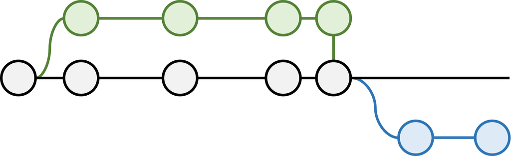

## Linking to RStudio

[figure not shown]

## Useful resources

[figure not shown]

- Introduction to GitHub presentation ([slides](https://speakerdeck.com/alicebartlett/git-for-humans) and [video](https://www.youtube.com/watch?v=eWxxfttcMts))
- All you need to know about GitHub in their [help](https://help.github.com/en) pages
- Detailed book about git, GitHub and R ([here](https://happygitwithr.com/))
- Detailed overview of RStudio, git and GitHub ([here](http://r-pkgs.had.co.nz/git.html))
- A game to help us think about git branches ([here](https://learngitbranching.js.org/))
- ONS GitHub introductory course ([here](https://github.com/datasciencecampus/version-control-with-git-github))